# Coupon redemption propensity

## Test-set performance

```python
evaluation = evaluate_classification_model(model, X_test, y_test)
metrics_df = pd.DataFrame.from_dict(evaluation["metrics"], orient="index", columns=["score"])
metrics_df
```

|  | score |
| --- | --- |
| accuracy | 0.788719 |
| precision | 0.324074 |
| recall | 0.655431 |
| f1 | 0.433705 |
| roc_auc | 0.784818 |

**Test-set metrics:** accuracy ~0.79, precision ~0.32, recall ~0.66, F1 ~0.43, ROC AUC ~0.78.

- Recall is moderately high, so we catch most redeemers; precision is modest, reinforcing rank-based targeting.
- ROC AUC shows solid ordering ability; use score deciles rather than a hard 0.5 cutoff. **Recommendation:** Use the score to rank households and choose decile cutoffs based on budget and desired reach.

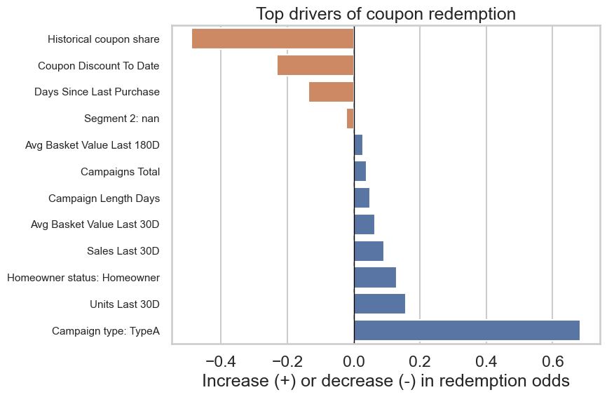

```python
# Top drivers of coupon redemption (logistic coefficients)
preprocessor = model.named_steps["preprocessor"]
log_reg = model.named_steps["logistic"]

num_features = preprocessor.transformers_[0][2]
ohe = preprocessor.named_transformers_["cat"]
cat_features = ohe.get_feature_names_out(preprocessor.transformers_[1][2])
feature_names = list(num_features) + list(cat_features)

coef = log_reg.coef_[0]
importance_df = pd.DataFrame({"feature": feature_names, "coefficient": coef})
importance_df["importance"] = importance_df["coefficient"].abs()

# Business-friendly labels

def friendly_label(feat: str) -> str:
    if feat.startswith("campaign_type_"):
        return f"Campaign type: {feat.split('_', 2)[-1]}"
    if feat.startswith("HOMEOWNER_DESC_"):
        val = feat.replace("HOMEOWNER_DESC_", "").replace("_", " ")
        return f"Homeowner status: {val}"
    if feat.startswith("KID_CATEGORY_DESC_"):
        val = feat.replace("KID_CATEGORY_DESC_", "").replace("_", " ")
        return f"Kids in HH: {val}"
    if feat.startswith("classification_"):
        parts = feat.split("_", 2)
        grp = parts[1] if len(parts) > 1 else ""
        val = parts[2].replace("_", " ") if len(parts) > 2 else ""
        return f"Segment {grp}: {val}"
    if feat == "coupon_share_to_date":
        return "Historical coupon share"
    if feat == "tenure_days":
        return "Tenure (days)"
    return feat.replace("_", " ").title()

TopN = 12
selected = importance_df.sort_values("importance", ascending=False).head(TopN)
selected["display"] = selected["feature"].apply(friendly_label)
selected = selected.sort_values("coefficient", ascending=True)

fig, ax = plt.subplots(figsize=(9, 6))
sns.barplot(
    data=selected,
    y="display",
    x="coefficient",
    palette=["#4c72b0" if v > 0 else "#dd8452" for v in selected["coefficient"]],
    ax=ax,
)
ax.axvline(0, color="black", linewidth=1)
ax.set_xlabel("Increase (+) or decrease (-) in redemption odds")
ax.set_ylabel("")
ax.set_title("Top drivers of coupon redemption")
ax.tick_params(axis="y", labelsize=11)
plt.tight_layout()
```

**Business takeaways (drivers):**

- TypeA campaigns drive the largest increase in redemption odds; recent purchase intensity (units/sales/avg basket last 30d) also pushes odds up.
- Longer campaign windows and households with more total campaigns respond better, suggesting benefit from repeated exposure.
- High historical coupon share and long time since last purchase reduce redemption odds—heavy past coupon users and lapsed shoppers are less responsive.

**Recommendation:** Lead with TypeA campaigns for recent, active shoppers; use shorter or lighter offers for high historical coupon users and re-engagement tactics for lapsed shoppers.